# Project 2: Biomedical & Clinical Informatics

Merrimack College DSE6630: Healthcare & Life Sciences Analytics

Ryan Canfield, Malek Sabri, Tiffany Acosta

30 April 2024

# 1 Introduction

#### Adventure 1. [Minimal coding, focus is on understanding cleaning, pre-processing, and the ML analyses we performed here.]

Choose ONE other condition (anything other than pneumonia) and run through the analyses again, using our same target variable. You will update your question, hypotheses, and predictions, but will be able to re-use all of the other code with very minor modifications. Credit will be based more on interpretation and not on coding.

For **Project 2**, you will have the option to **modify** and **run** the code in the `answers_demo2.R` file and run it in your markdown file, as I do below. Now, you don’t have to run the code right now unless you want to see it in action; if you do, make sure to give it a couple minutes to run, as it’s doing a lot in one fell swoop. Or, you can just skip ahead to the next section and load the data.

```
## [1] "Before encoding:"
##
##   Better than the National Benchmark No Different than National Benchmark
##                                  166                                 1517
##    Worse than the National Benchmark                                 <NA>
##                                   50                                 3083
## [1] "After encoding:"
##
##   -1    0    1 <NA>
##   50 1517  166 3083
## [1] "Before encoding:"
##
##       Better Than the National Rate No Different Than the National Rate
##                                 213                                2747
##        Worse Than the National Rate                                <NA>
##                                  96                                1760
## [1] "After encoding:"
##
##   -1    0    1 <NA>
##   96 2747  213 1760
## [1] "Before encoding:"
##
##       Better Than the National Rate No Different Than the National Rate
##                                  57                                2435
##        Worse Than the National Rate                                <NA>
##                                 111                                2213
## [1] "After encoding:"
##
##   -1    0    1 <NA>
##  111 2435   57 2213
## [1] "Before encoding:"
##
##       Better Than the National Rate No Different Than the National Rate
##                                  16                                2845
##        Worse Than the National Rate                                <NA>
##                                  74                                1881
## [1] "After encoding:"
##
##   -1    0    1 <NA>
##   74 2845   16 1881
```

[output cut: 23 more lines]

```
##  594 2194  336 1692
## [1] "Before encoding:"
##
##      Greater Than the National Average Payment
##                                            342
##         Less Than the National Average Payment
##                                            271
## No Different Than the National Average Payment
##                                           2281
##                                           <NA>
##                                           1922
## [1] "After encoding:"
##
##    0 <NA>
## 2281 2535
```

## 1.4 Load data from the end of the demo.

Load my version of the fully cleaned, encoded, & ready-to-proceed dataset from the end of Demo 2. These data are not yet ready for analysis (!) but we are picking up with that here.

```r
load("HEART_FAILURE_AnalyzefromDemo.Rdata")
```

# 2 Exploratory Data Analysis (Continued)

Table 1. List of possible target variables from the Heart failure-related hospital readmission data. Which one to choose?

[output not shown]

**Table 2. Possible target measure summaries**

| **Characteristic** | **N = 4,816**<sup>1</sup> |
| --- | --- |
| National Comparison Return Hospital Days |  |
| Better than average | 336 / 4,816 (7.0%) |
| Same as average | 2,194 / 4,816 (46%) |
| Worse than average | 594 / 4,816 (12%) |
| Unknown | 1,692 / 4,816 (35%) |
| Predicted Readmission Rate | 19.85 (2.02), 19.71 |
| (Missing) | 2,181 |
| Observed Readmission Rate | 20.5 (4.1), 20.2 |
| (Missing) | 2,511 |
| ExcessReadmissionRatio | 1.00 (0.07), 1.00 |
| (Missing) | 2,181 |
| Expected Readmission Rate | 19.82 (1.39), 19.84 |
| (Missing) | 2,181 |

<sup>1</sup> n / N (%); Mean (SD), Median

#### Example with `geom_violin()`:

Here I am leaving the `NA` data (which I relabelled as `Unknown`) to get a sense for the degree of missingness.

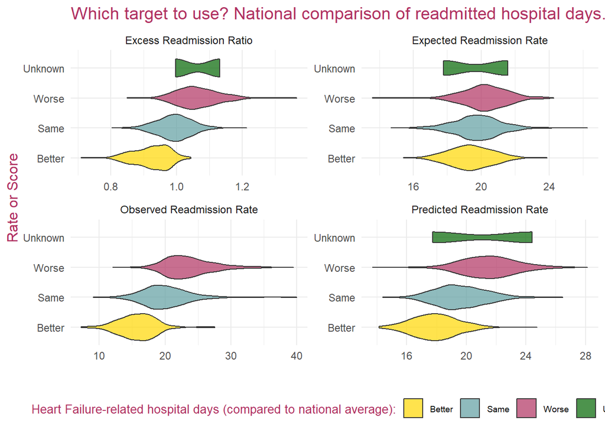

#### Example with `geom_density()`:

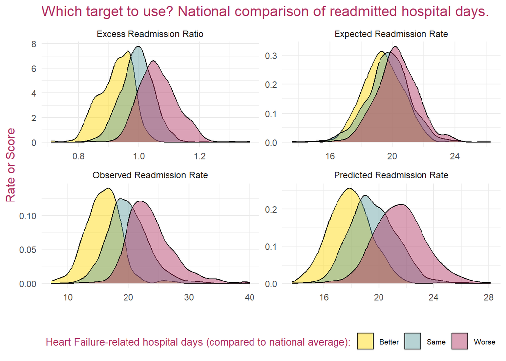

### 2.3 What is the distribution of various hospital metrics across heart failure-related readmission as compared to the national average?

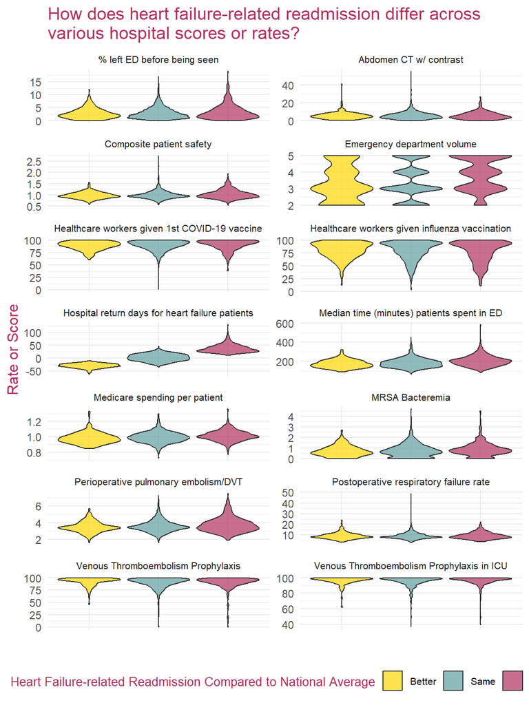

### 2.4 What is the relationship of heart failure-related hospital readmissions to the various hospital metrics?

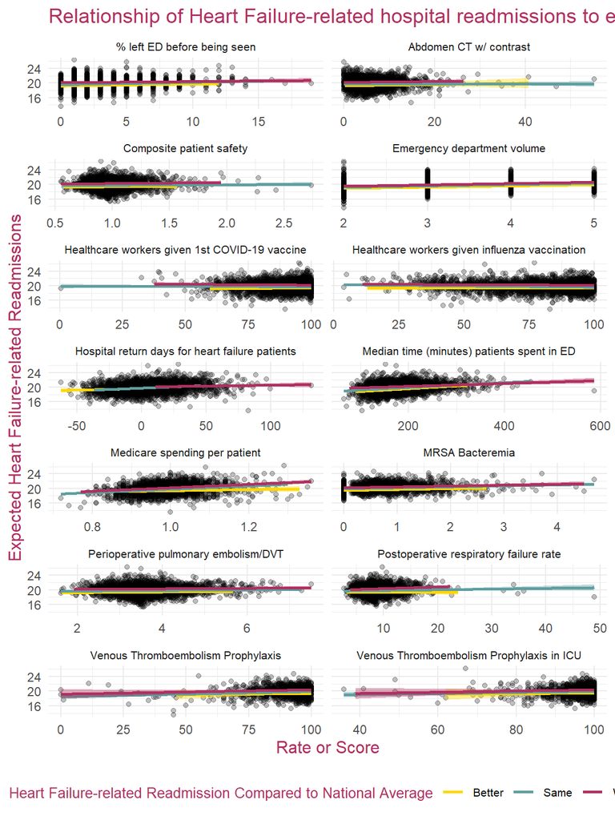

##### **Question 1**: [1 point]

Use the code above, or write your own *de novo*, to explore the relationships between the expected heart failure readmissions and the `HcahpsLinear...` variables.

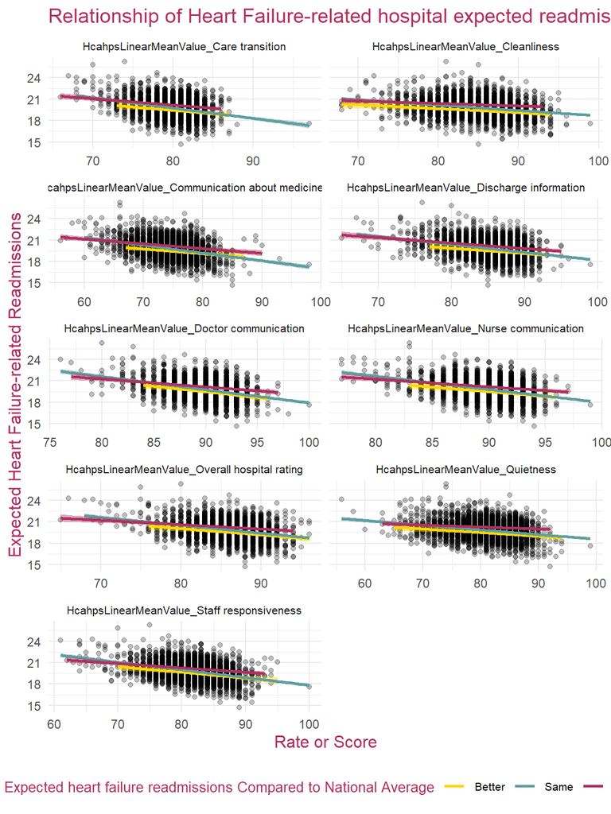

```r
# #Malek
hcahps_data <- HEART_FAILURE_AnalyzeDemo %>%
  rename(NatlComparisonHospitalDays = `ComparedToNational_Hospital return days for heart failure patients`) %>%
  select(contains(c("NatlComparisonHospitalDays", "ExpectedReadmissionRate", "HcahpsLinear"))) %>%
  pivot_longer(-c(1, 2, 12), names_to = "Variable2", values_to = "Value2") %>%
  drop_na() %>%
  mutate(Variable2 = gsub("Score_", "", Variable2)) %>%
  mutate(Variable2 = ifelse(Variable2 == "Average (median) time patients spent in the emergency department before leaving from the visit A lower number of minutes is better", "Median time (minutes) patients spent in ED",
                    ifelse(Variable2 == "CMS Medicare PSI 90: Patient safety and adverse events composite", "Composite patient safety",
                    ifelse(Variable2 == "Abdomen CT Use of Contrast Material", "Abdomen CT w/ contrast",
                    ifelse(Variable2 == "Perioperative pulmonary embolism or deep vein thrombosis rate", "Perioperative pulmonary embolism/DVT",
                    ifelse(Variable2 == "Percentage of healthcare personnel who completed COVID-19 primary vaccination series", "Healthcare workers given 1st COVID-19 vaccine",           ifelse(Variable2 == "Left before being seen", "% left ED before being seen",
                    ifelse(Variable2 == "Intensive Care Unit Venous Thromboembolism Prophylaxis", "Venous Thromboembolism Prophylaxis in ICU", Variable2))))))),
         NatlComparisonHospitalDays = ifelse(NatlComparisonHospitalDays == 1, "Better",
                                      ifelse(NatlComparisonHospitalDays == -1, "Worse",
                                      ifelse(NatlComparisonHospitalDays == 0, "Same", NatlComparisonHospitalDays))))


hcahps_data %>%
  ggplot(aes(y = ExpectedReadmissionRate,
             x = Value2)) +
    geom_point(alpha = 0.25) +
    geom_smooth(aes(fill = as.factor(NatlComparisonHospitalDays),
                    color = as.factor(NatlComparisonHospitalDays)),
                method = "lm",
                se = TRUE,
                show.legend = TRUE) +
    labs(title = "Relationship of Heart Failure-related hospital expected readmissions to HcahpsLinear variables",
         x = "Rate or Score",
         y = "Expected Heart Failure-related Readmissions",
         color = "Expected heart failure readmissions Compared to National Average") +
    scale_fill_manual(values = c("gold", "cadetblue", "maroon")) +
    scale_color_manual(values = c("gold", "cadetblue", "maroon"),
                       labels = c("Better", "Same", "Worse")) +
    guides(fill = "none", color = guide_legend(override.aes = list(fill = NA))) +
    theme_minimal() +
    theme(legend.position = "bottom",
          strip.text = element_text(size = 8),
          legend.text = element_text(size = 8),
          legend.title = element_text(size = 10),
          title = element_text(size = 12, color = "maroon")) +
    facet_wrap(~ Variable2,
               scales = "free_x",
               ncol = 2)
```

##### **Question 2**: [1 point]

What relationships do you find most compelling from your graphic and why? Also, name one outstanding question you have at this point, whether it is about the data, the data collection, or something more speculative.

> #Malek Here I would not say that there is one specific relationship that stands out the most. The biggest question that I have as of now is that I wonder if the relationship of the variables is similar based on the size or geographical location of the hospital.

#### Bias and Limitation

##### **Question 3**: [1 point]

All studies have bias (introduced or systemic error) and limitations (failure to fully explain something). We could go more deeply into these concepts, but for now I want you to take a stab and just brainstorming either ways we might have bias OR the limitations of using this target variable. You do not need to answer both, but you’re welcome to do so. You can read more about bias [here](https://www.ncbi.nlm.nih.gov/books/NBK574513/) or see some deeper explanations of limitations [here](https://www.aje.com/arc/how-to-write-limitations-of-the-study/). You do not need to write a lot; just 2-3 sentences. I am simply asking you to pause and reflect on our choices here before we proceed.

> #Malek This answer is pretty much identical to the one from the first half of this project. One potential bias in using the Expected readmission rate as our target variable is selection bias. The thing that is making me weary here is that the data is pretty reliant on historical data which may or may not be up to date. Thus, if one hospital has more data than another that is really covering all the bases then I believe this would definitely be shown in the outcomes.

# 3 Pre-processing and Feature Selection

### 3.1.1 Dropping the targets we aren’t planning to use. [Manual Method]

```r
## Clean up the column names quickly - remove "Score_", "HcahpsLinearMeanValue_", "_Payment"
colnames(HEART_FAILURE_AnalyzeDemo) <- gsub('Score_|HcahpsLinearMeanValue_|_Payment', '', colnames(HEART_FAILURE_AnalyzeDemo))
```

##### **Question 4**: [1 point]

Why do you think I choose to keep `Hospital return days for pneumonia patients` and `ComparedToNational_Hospital return days for pneumonia patients`? Do you agree with my choice? Why or why not? What analytic pitfalls are there to including them?

> #Malek Again, this answer is going to be pretty similar to part 1. I would say that I do agree with your choice… Probably always best to agree with you in these situations as there is likely a reason why you did what you did haha. Anyways, I like keeping both of them in there as it gives some kind of standard for us to use and compare with. As long as things aren’t becoming redundant, which I don’t believe they are in this case, then we should be in good shape. In terms of the new target variable, I do believe that this is still useful, but just on the heart failute side as these two pieces of data can be useful when comparing to eachother. Especially because of the many factors that go into heart failure this can be a good way to see regional differences compared with national.

### 3.1.2 Dropping any features with near-zero variance. [Automated Method]

Table 3. Columns dropped due to near-zero variance.

| Variable |
| --- |
| PaymentCategory for heart failure patients |
| ComparedToNational_Postoperative respiratory failure rate |
| ComparedToNational_Perioperative pulmonary embolism or deep vein thrombosis rate |
| Sample_Emergency department volume |

##### **Question 5**: [1 point]

If you are not familiar yet with the concept of **zero or near-zero variance**, do a little digging. Based on what you read, try to explain for your naive advocacy group stakeholders, why it’s important to remove the features with little variance.

##### **Question 6**: [1 point]

Why do I want to make sure unique identifiers, like `FacilityID`, are out of the dataframe for before I either run `nearZeroVar()` or proceeding with the rest of the analysis? What problems does keeping them in there create?

> #Malek Unique identifiers need to get removed because they can cause a disturbance in the models and understanding the data. These are not data points we are analyzing and are really just indicators of facilites in this case and thus there isn’t anything to analyze

## 3.2 Assess missingness & devise an imputation plan

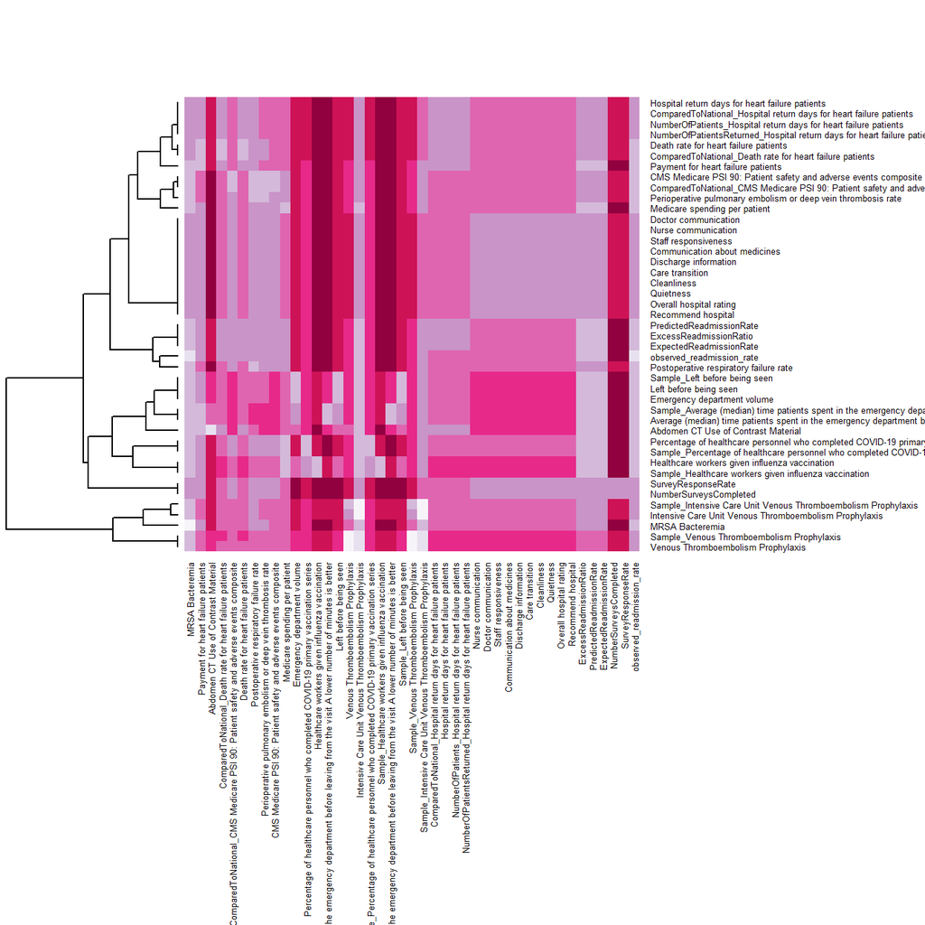

```r
# Drop ID and State and analyze the missingness in pairs using the mice package
p <- md.pairs(HEART_FAILURE_AnalyzeDemo[,-c(1:2)])
## Calculate pairwise pattern of missingness, where value is missing in both columns being compared.
df <- as.matrix(p$mr/(p$mr+p$mm))
```

##### **Question 7**: [1 point]

What columns seem to be most correlated in terms of missingness with our target, `PredictedReadmissionRate`? Does this give you any cause for concern?

> #Malek Interestingly enough, the heat map is showing the same missingness columns which are SurveyResponseRate, healthcare workers given influenza vaccination, and median time patients spent in ED

### Drop the rows that are missing from the target variable.

```
## [1] "Rows: 2635"  "Columns: 45"
```

## 3.3 Split into training & testing sets.

##### **Question 8**: [2 points]

There are three parts to this question to get it to all come together correctly. **Practice reading R code** #Malek * Comment the function to explain what it does (I’ve defined the arguments for you) * Run the function (fill in the blank) * Fill in the missing piece in the partitioning chunk below

```r
#Malek
calcSplitRatio <- function(p = NA, df) {
  ## @p  = the number of parameters. by default, if none are provided, the number of columns (predictors) in the dataset are used
  ## @df = the dataframe that will be used for the analysis

  ##With no p, it is set to the number of columns in the dataframe - 1
  if(is.na(p)) {
    p <- ncol(df) -1   ##parameters is columns - 1
  }

  ##So now we are builiding the test set size and using that important formula of (1/sqrt(p))
  test_N <- (1/sqrt(p))*nrow(HEART_FAILURE_AnalyzeDemo)
  ##Determines the proportion of test set compared to the whole data frame
  test_prop <- round((1/sqrt(p))*nrow(HEART_FAILURE_AnalyzeDemo)/nrow(HEART_FAILURE_AnalyzeDemo), 2)
  ##Training proportion, whatever the test isn't
  train_prop <- 1-test_prop

  ##Prints best ratio
  print(paste0("The ideal split ratio is ", train_prop, " : ", test_prop, " training : testing"))

  ##Returns training proportion
  return(train_prop)
}

## Fill in the blanks to run:
train_prop <- calcSplitRatio(df = HEART_FAILURE_AnalyzeDemo)
```

```
## [1] "The ideal split ratio is 0.85 : 0.15 training : testing"
```

**Hint**: One important note here is that if the number of parameters are not provided (which is true for the starter code I gave you to run it - it does NOT pass any parameters to that argument!), then by default our function is designed to take the number of columns of the dataframe and subtract one for the target variable. Neat, huh?

```r
#Malek
ind <- createDataPartition(HEART_FAILURE_AnalyzeDemo$ExpectedReadmissionRate,
                            p = train_prop,
                            list = FALSE)

HFtrain <- HEART_FAILURE_AnalyzeDemo[ind, ]
HFtest <- HEART_FAILURE_AnalyzeDemo[-c(ind), ]
```

## 3.4 Impute missing variables using `missForest`.

Let’s look at a quick summary of the results.

Table 4. missForest OOB Error Rates for the imputed variables, training dataset

| OOB Error | Variable |
| --- | --- |
| **MSE** |  |
| 0.29 | MRSA Bacteremia |
| 1164920.01 | Payment for heart failure patients |
| 17.82 | Abdomen CT Use of Contrast Material |
| 2.20 | Death rate for heart failure patients |
| 7.16 | Postoperative respiratory failure rate |
| 0.45 | Perioperative pulmonary embolism or deep vein thrombosis rate |
| 0.01 | CMS Medicare PSI 90: Patient safety and adverse events composite |
| 0.00 | Medicare spending per patient |
| 79.86 | Percentage of healthcare personnel who completed COVID-19 primary vaccination series |
| 249.82 | Healthcare workers given influenza vaccination |
| 1291.62 | Average (median) time patients spent in the emergency department before leaving from the visit A lower number of minutes is better |
| 4.15 | Left before being seen |
| 72.44 | Venous Thromboembolism Prophylaxis |
| 24.91 | Intensive Care Unit Venous Thromboembolism Prophylaxis |
| 1922898.58 | Sample_Percentage of healthcare personnel who completed COVID-19 primary vaccination series |
| 2114781.62 | Sample_Healthcare workers given influenza vaccination |
| 11432003.57 | Sample_Average (median) time patients spent in the emergency department before leaving from the visit A lower number of minutes is better |
| 309426214.54 | Sample_Left before being seen |
| 2829775.47 | Sample_Venous Thromboembolism Prophylaxis |
| 311421.05 | Sample_Intensive Care Unit Venous Thromboembolism Prophylaxis |
| 166.05 | Hospital return days for heart failure patients |
| 4437.37 | NumberOfPatients_Hospital return days for heart failure patients |
| 490.24 | NumberOfPatientsReturned_Hospital return days for heart failure patients |
| 0.94 | Nurse communication |
| 1.76 | Doctor communication |
| 4.46 | Staff responsiveness |
| **PCF** |  |
| 4.29 | Communication about medicines |
| 4.61 | Discharge information |
| 1.17 | Care transition |
| 11.47 | Cleanliness |
| 12.97 | Quietness |
| 1.04 | Overall hospital rating |
| 2.57 | Recommend hospital |
| 0.00 | ExcessReadmissionRatio |
| 0.00 | PredictedReadmissionRate |
| 333906.38 | NumberSurveysCompleted |
| 0.00 | SurveyResponseRate |
| 1.76 | observed_readmission_rate |
| 0.02 | Emergency department volume |
| 0.12 | ComparedToNational_MRSA Bacteremia |
| 0.06 | ComparedToNational_Death rate for heart failure patients |
| 0.05 | ComparedToNational_CMS Medicare PSI 90: Patient safety and adverse events composite |
| 0.09 | ComparedToNational_Hospital return days for heart failure patients |

##### **Question 9**: [1 point]

What does `MSE` and `PCF` indicate here? You may find looking at the `missForest` [Vignette](https://stat.ethz.ch/education/semesters/ss2012/ams/paper/missForest_1.2.pdf) helpful. How is the random forest that was performed here similar to what we performed on the gene expression data? How does this differ?

> #Malek This question was kind of confusing for me, but MSE I believe is the mean squared error. What is being measured in the mean squared error is the average of all the differences between the true and the estimated values. PCF, partial complete fraction looks at the proportion of correctly observed values. The thing that I want to point out here is that in gene expression the forests are applied based on gene expression patterns, but on the flip side missforest looks at missing values and builds forests from there I believe.

```r
HFimputedTrain <- HFimputedTrain$ximp %>%
  ## Put the original State and target variables back on
  mutate(State = HFtrain$State,
         ExpectedctedReadmissionRate = HFtrain$ExpectedctedReadmissionRate) %>%
  ## Convert the factors back to character type...
  mutate_at(c("Emergency department volume",
              "ComparedToNational_CMS Medicare PSI 90: Patient safety and adverse events composite",
              "ComparedToNational_MRSA Bacteremia",
              "ComparedToNational_Death rate for heart failure patients",
              "ComparedToNational_Hospital return days for heart failure patients"),
            as.character) %>%
  ## ... so we can then convert them back to numeric type.
  mutate_at(c("Emergency department volume",
              "ComparedToNational_CMS Medicare PSI 90: Patient safety and adverse events composite",
              "ComparedToNational_MRSA Bacteremia",
              "ComparedToNational_Death rate for heart failure patients",
              "ComparedToNational_Hospital return days for heart failure patients"),
            as.numeric)


HFimputedTrain <- cbind(HFimputedTrain, HFtrain$ExpectedReadmissionRate)
names(HFimputedTrain)[names(HFimputedTrain) == "HFtrain$ExpectedReadmissionRate"] <- "ExpectedReadmissionRate"


## Save data files so they can be loaded for future use
# save(imputedTrain, file = "imputedTrain.Rdata")
```

##### **Question 10**: [1 point]

Now repeat the imputation steps for the `test` dataset, storing it into `imputedTest`.

```r
## Ryan C

# Remove encoded categorical variables for imputation, plus the target and state (which have no missing)
data_sans_encoded2 = HFtest %>%
  select(-ExpectedReadmissionRate,
         -State,
         -`Emergency department volume`,
         -contains("ComparedToNational"))

data_cat2 = HFtest %>%
  select(`Emergency department volume`,
         contains("ComparedToNational")) %>%
  mutate_all(as.factor)

# Stitch them back together:
temptest <- cbind(data_sans_encoded2, data_cat2)

# Impute missing values using missForest
HFimputedTest <- missForest(temptest,
                          variablewise = TRUE,
                          verbose = FALSE)

## Malek
HFimputedTest <- HFimputedTest$ximp %>%
  ## Put the original State and target variables back on
  mutate(State = HFtest$State,
         ExpectedReadmissionRate = HFtest$ExpectedReadmissionRate) %>%
  ## Convert the factors back to character type...
  mutate_at(c("Emergency department volume",
              "ComparedToNational_CMS Medicare PSI 90: Patient safety and adverse events composite",
              "ComparedToNational_MRSA Bacteremia",
              "ComparedToNational_Death rate for heart failure patients",
              "ComparedToNational_Hospital return days for heart failure patients"),
            as.character) %>%
  mutate_at(c("Emergency department volume",
              "ComparedToNational_CMS Medicare PSI 90: Patient safety and adverse events composite",
              "ComparedToNational_MRSA Bacteremia",
              "ComparedToNational_Death rate for heart failure patients",
              "ComparedToNational_Hospital return days for heart failure patients"),
            as.numeric)


## Save data files to be used in future
# save(imputedTest, file = "imputedTest.Rdata")
```

##### **Question 11**: [1 point]

Quickly explore how well the imputation did by choosing at least one numeric variable and one of the categorical variables. Did the distributions or frequencies change drastically?

```r
# Your code here.
```

Struggling? Here’s my solution:

```r
# source(file = "answer_question11.R", echo = TRUE)
```

## 3.5 Transformation & Scaling

**In other words: is our target variable approximately normally distributed?**

[figure not shown]

##### **Question 12**: [1 point]

Why is a histogram, or even a Q-Q plot, an insufficient way to assess whether a distribution is approximately normal?

> Your answer here.while histograms and Q-Q plots are valuable tools, their limitations necessitate the use of complementary statistical tests to more accurately assess whether a distribution is approximately normal.

##### **Question 13**: [1 point]

Apply a Shapiro-Wilk test for normality using the `shapiro.test()` function. What does it indicate about your distribution? (**Note**: Shapiro tests are only reliable for $N < 5000$, but it is fine to perform here.)

```r
shapiro_test_result <- shapiro.test(HFimputedTrain$ExpectedReadmissionRate)

# Printing the result
print(shapiro_test_result)
```

```
##
##  Shapiro-Wilk normality test
##
## data:  HFimputedTrain$ExpectedReadmissionRate
## W = 0.99569, p-value = 0.000004652
```

Shapiro-Wilk normality test

### 3.5.1 Box-Cox Transformation

```r
bc_data <- BoxCoxTrans(HFimputedTrain$ExpectedReadmissionRate)
bc_data
```

```
## Box-Cox Transformation
##
## 2243 data points used to estimate Lambda
##
## Input data summary:
##    Min. 1st Qu.  Median    Mean 3rd Qu.    Max.
##   13.57   18.98   19.84   19.82   20.68   26.27
##
## Largest/Smallest: 1.94
## Sample Skewness: 0.00106
##
## Estimated Lambda: 1.1
## With fudge factor, no transformation is applied
```

Now apply the Box-Cox transformation:

```r
HFimputedTrain$bc_ExpectedReadmissionRate <- predict(bc_data, HFimputedTrain$ExpectedReadmissionRate)
```

[figure not shown]

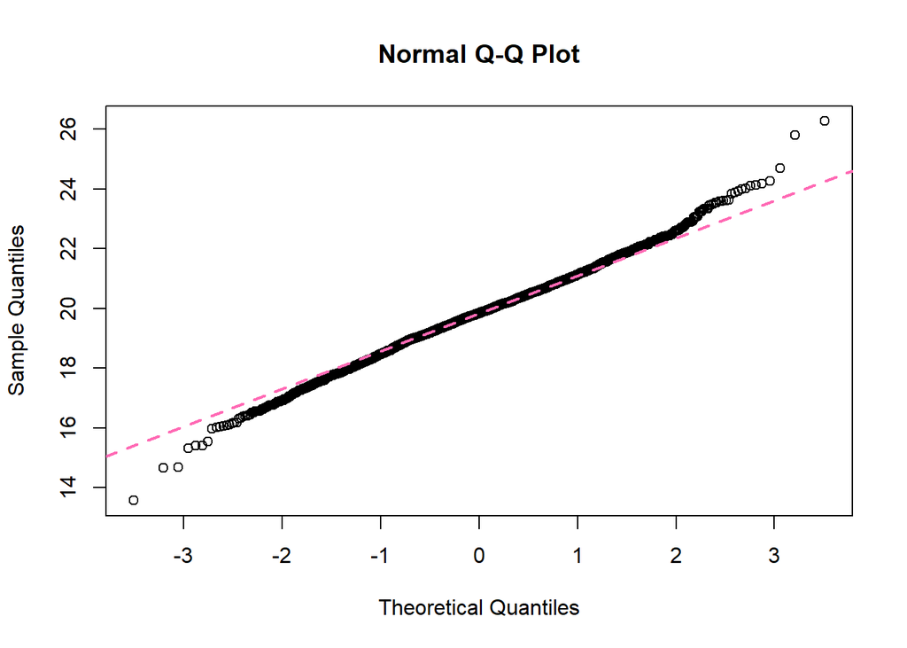

##### **Question 14**: [1 point]

Now repeat all of the steps to perform a Box-Cox transform on your own to the `imputedTest` data. Why do you think we need to transform the test data too? > Tiffany > Your answer here.If train data is transformed, we must transform test data as well to get more acurate results

```r
## Ryan C
bc_data2 <- BoxCoxTrans(HFimputedTest$ExpectedReadmissionRate)
HFimputedTest$bc_ExpectedReadmissionRate <- predict(bc_data2, HFimputedTest$ExpectedReadmissionRate)
```

### 3.5.2 Centering & Scaling

##### **Question 15**: [1 point]

## Ryan C

Make a copy of the imputed training set, drop our original, non-Box-Cox transformed target from the dataset, and then center and scale the whole training set using the `scale()` function in R. I called my dataset `readyTrain`, so if you name it anything else just note you’ll have to update subsequent code. Then, **do the same thing for the test data**!

```r
center_and_scale <- function(data) {
  scaled_data <- scale(data)
  return(scaled_data)
}

HFimputedTrain <- HFimputedTrain %>% select(-ExpectedReadmissionRate)
HFimputedTest <- HFimputedTest %>% select(-ExpectedReadmissionRate)

HFreadyTrain <- center_and_scale(HFimputedTrain)
HFreadyTest <- center_and_scale(HFimputedTest)

HFreadyTrain <- HFreadyTrain %>% data.frame()
HFreadyTest <- HFreadyTest %>% data.frame()
```

# 4 Unsupervised Learning Methods

## 4.1 Principal Component Analysis

```r
pca <- prcomp(HFreadyTrain)
summary(pca)
```

```
## Importance of components:
##                           PC1    PC2     PC3     PC4     PC5     PC6     PC7
## Standard deviation     3.1235 2.6628 1.76872 1.52803 1.38284 1.31976 1.24342
## Proportion of Variance 0.2168 0.1576 0.06952 0.05189 0.04249 0.03871 0.03436
## Cumulative Proportion  0.2168 0.3744 0.44389 0.49578 0.53827 0.57698 0.61133
##                            PC8     PC9    PC10    PC11    PC12   PC13    PC14
## Standard deviation     1.16410 1.12022 1.09142 1.02015 0.98436 0.9581 0.94538
## Proportion of Variance 0.03011 0.02789 0.02647 0.02313 0.02153 0.0204 0.01986
## Cumulative Proportion  0.64145 0.66934 0.69581 0.71893 0.74047 0.7609 0.78073
##                           PC15    PC16    PC17    PC18    PC19    PC20    PC21
## Standard deviation     0.93358 0.91871 0.82572 0.77974 0.77332 0.74912 0.73811
## Proportion of Variance 0.01937 0.01876 0.01515 0.01351 0.01329 0.01247 0.01211
## Cumulative Proportion  0.80010 0.81885 0.83400 0.84751 0.86080 0.87327 0.88538
##                           PC22    PC23    PC24    PC25    PC26   PC27    PC28
## Standard deviation     0.71546 0.69359 0.66557 0.64252 0.62688 0.6148 0.57174
## Proportion of Variance 0.01138 0.01069 0.00984 0.00917 0.00873 0.0084 0.00726
## Cumulative Proportion  0.89676 0.90745 0.91729 0.92647 0.93520 0.9436 0.95086
##                           PC29    PC30   PC31    PC32    PC33    PC34    PC35
## Standard deviation     0.49931 0.49228 0.4742 0.46990 0.45461 0.43526 0.42023
## Proportion of Variance 0.00554 0.00539 0.0050 0.00491 0.00459 0.00421 0.00392
## Cumulative Proportion  0.95640 0.96179 0.9668 0.97169 0.97628 0.98049 0.98442
##                           PC36    PC37    PC38    PC39    PC40    PC41    PC42
## Standard deviation     0.39399 0.36864 0.34001 0.30374 0.28966 0.21701 0.19615
## Proportion of Variance 0.00345 0.00302 0.00257 0.00205 0.00186 0.00105 0.00086
## Cumulative Proportion  0.98787 0.99089 0.99346 0.99551 0.99737 0.99842 0.99927
##                           PC43    PC44    PC45
## Standard deviation     0.16174 0.07564 0.02958
## Proportion of Variance 0.00058 0.00013 0.00002
## Cumulative Proportion  0.99985 0.99998 1.00000
```

Let’s also look at this as a Scree Plot.

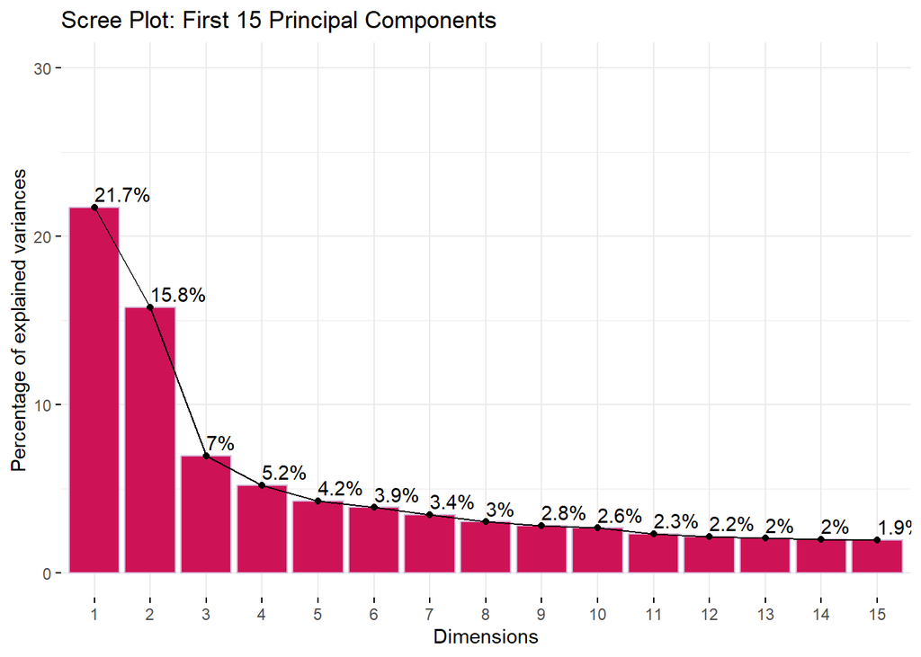

##### **Question 16**: [1 point]

Using the ‘elbow’ method of the scree plot - the point at which the percentage of variance explained seems to level off - approximately how many principal components would be significant to explain the total variation in the training data set? (**Hint**: if it’s not super obvious, that’s actually informative!)

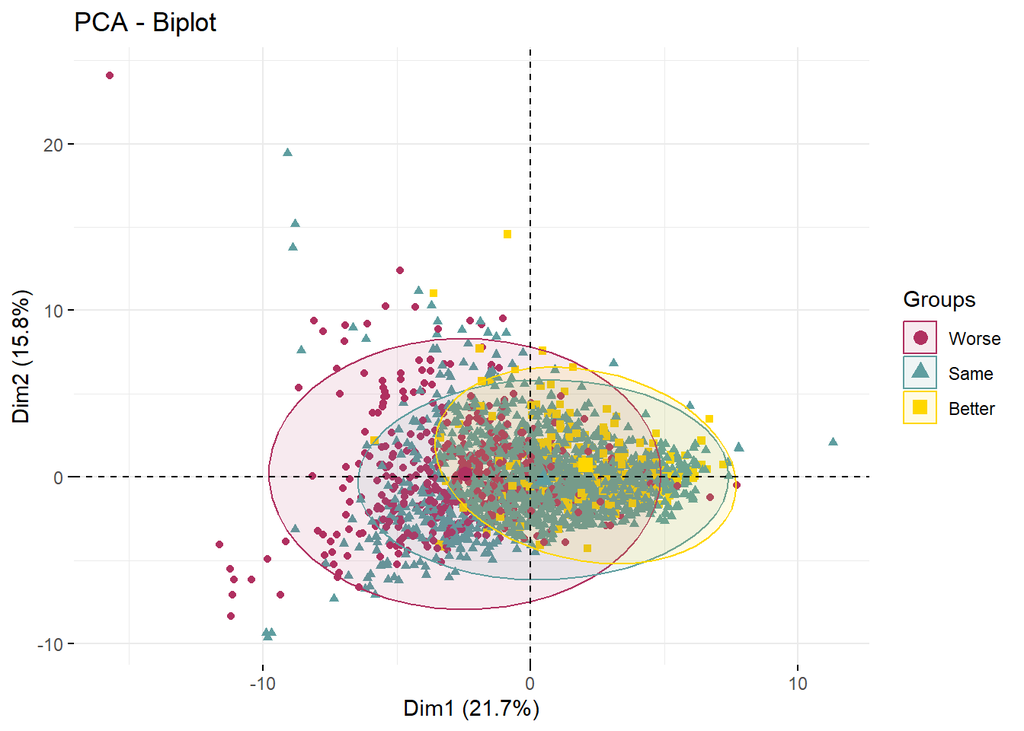

##### **Question 17**: [1 point]

On principal components 1 and 2 (the PCs that account for the **most** variance in the training data), do you see any pattern (i.e., clustering) relative to the hospital return days for pneumonia patients compared to the national average? Why or why not?

[figure not shown]

## 4.2 *k*-means Clustering

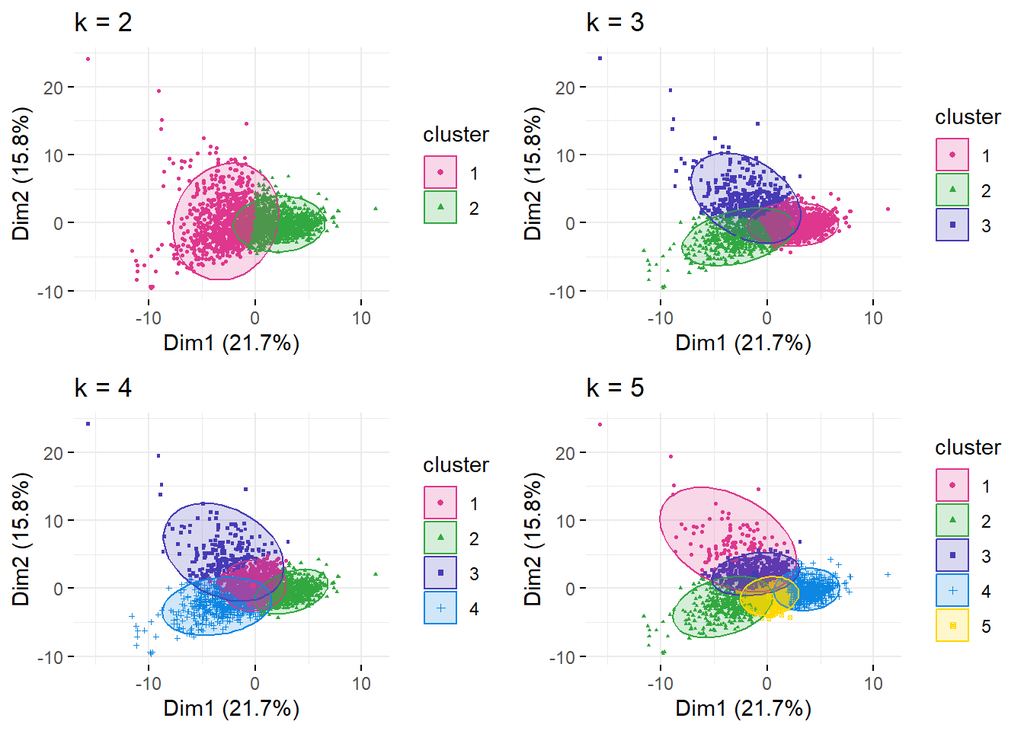

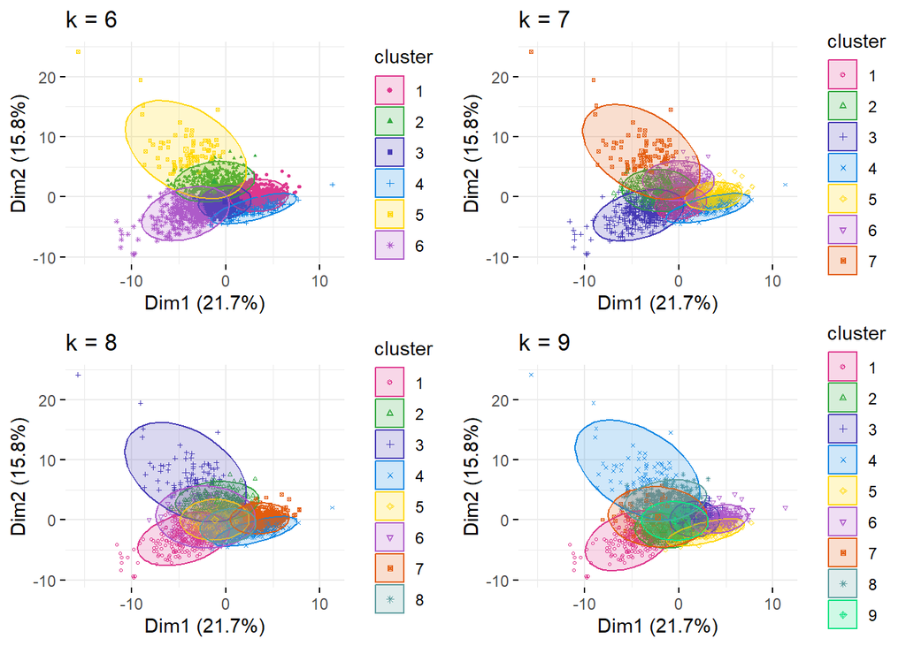

##### **Question 18**: [1 point]

Which number of clusters, $k$, do you think has the best explanatory power? Is it hard to tell?

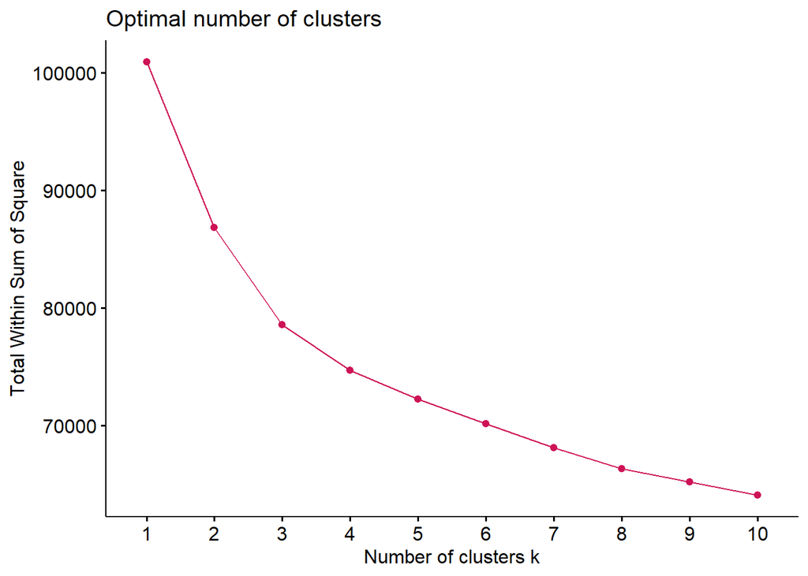

#### **Question 19**: [1 point]

What is the **within sum of squares** and what exactly is it measuring here? By the elbow method, which $k$ is the optimal number of clusters? Did it agree with your choice from the other heuristic method?

## 4.3 Segmentation Analysis

#### **Question 20**: [1 point]

Let’s explore the clusters - segments - of the hospitals based on their average values from the **original** dataset. Your task is to add comments to this code chunk.

```r
## Uses the KMeans function on the readyTrain dataset and stores it in kmeansResult. Below are the parameters.
HFkmeansResult <- kmeans(HFreadyTrain,
                         centers = 3,            ## Specifies 3 clusters for k-means clustering.
                         nstart = 50,            ## Number of initial sets of cluster centers to try.
                         iter.max = 1000,        ## Maximum number of iterations.
                         algorithm = "MacQueen") ## Algorithm used for clustering.

## Adds a column called Cluster based on result.
HFkmeansTrain <- HFimputedTrain %>%
  mutate(Cluster = HFkmeansResult$cluster) %>%
  clean_names()
```

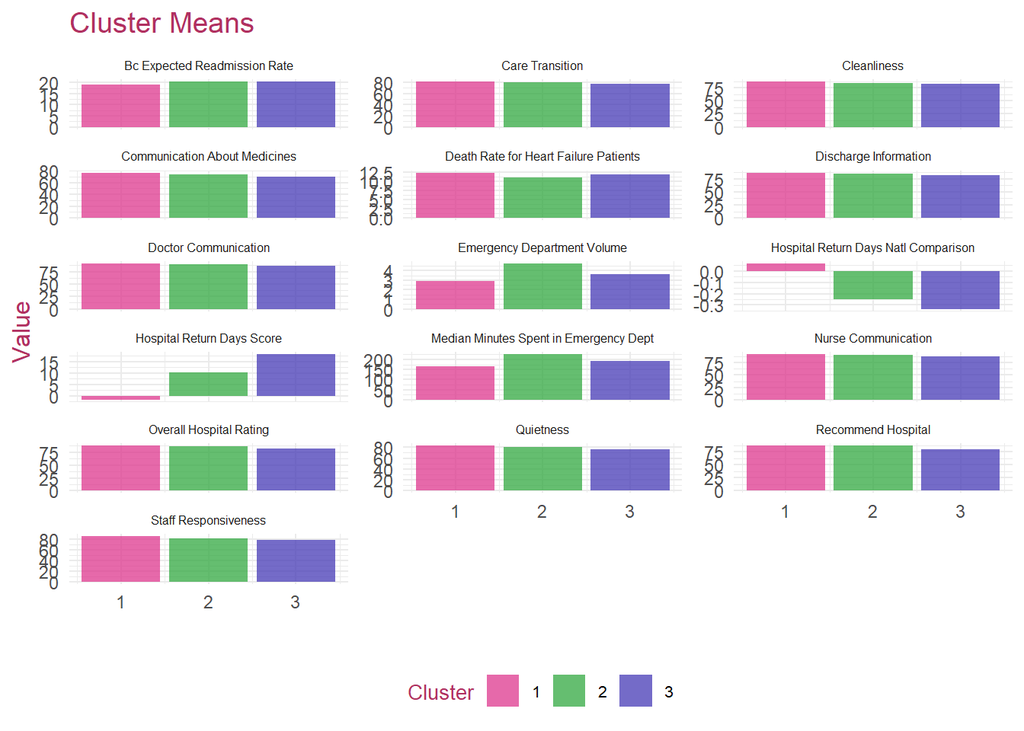

```r
## Specifies which variables to import for PCA.
pcaImportantVars <- c("overall_hospital_rating",
                      "care_transition",
                      "nurse_communication",
                      "recommend_hospital",
                      "staff_responsiveness",
                      "communication_about_medicines",
                      "doctor_communication",
                      "discharge_information",
                      "death_rate_for_heart_failure_patients",
                      "quietness",
                      "average_median_time_patients_spent_in_the_emergency_department_before_leaving_from_the_visit_a_lower_number_of_minutes_is_better",
                      "hospital_return_days_for_heart_failure_patients",
                      "emergency_department_volume",
                      "compared_to_national_hospital_return_days_for_heart_failure_patients",
                      "cleanliness",
                      "bc_expected_readmission_rate")


HFkmeansTrain %>%
  select(all_of(pcaImportantVars), cluster) %>%
  rename("Hospital Return Days Score" = hospital_return_days_for_heart_failure_patients,
         "Hospital Return Days Nat'l Comparison" = compared_to_national_hospital_return_days_for_heart_failure_patients,
         "Median Minutes spent in Emergency Dept" = average_median_time_patients_spent_in_the_emergency_department_before_leaving_from_the_visit_a_lower_number_of_minutes_is_better) %>%
  clean_names(case = "title") %>%
  group_by(Cluster) %>%
  summarise_if(is.numeric, mean, na.rm = TRUE) %>%
  pivot_longer(-1, names_to = "Measure", values_to = "Value") %>%
  ggplot(aes(x = Cluster, y = Value, fill = as.factor(Cluster))) +
    geom_col(alpha = 0.75) +
    scale_fill_manual(values = myPal) +
    labs(title = "Cluster Means",
         x = "",
         fill = "Cluster") +
    theme_minimal() +
    theme(legend.position = "bottom",
          strip.text = element_text(size=6),
          legend.text = element_text(size = 8),
          legend.title = element_text(size = 10),
          title = element_text(size = 12, color = "maroon")) +
    facet_wrap(~Measure,
               scales = "free_y",
               ncol = 3)
```

#### **Question 21**: [1 point]

## Ryan C

Then come up with at least FOUR characteristics per cluster. You may choose to focus on different attributes for different clusters. Fill in the code for the table below. I start you out with two examples for Cluster 1, but feel free to add more! You are also welcome to rename Cluster 1 if you think of a catchier name than I chose!

Table 5. Hospital segmentation analysis: three types of broad groupings identified.

[output not shown]

## 4.4 Final Remarks on Segmentation

#### **Question 22**: [1 point]

## Ryan C

Make a recommendation for our client for 1-2 machine learning analyses **your team** would choose to use to test whether these clusters can be used for robust predictions of hospital performance for pneumonia patients. How would you know whether or not your predictions were robust? What would you look for or compare?

> I would recommend a DBSCAN and logistic regression to test and see if the clusters can predict heart failure outcomes accurately based on the given historical data. Then, I’d preform a decision tree analysis to try and understand the factors that influence the predictions made by those clusters. To check if predictions are robust, I’d just compare the predicted outcomes with actual outcomes from a new set of pneumonia patient data, and check different metricslike accuracy, sensitivity, and specificity. If the model consistently predicts outcomes across different datasets, it indicates robustness.

# 4 Supervised Learning Methods

#### **Question 23**: [1 point]

## Ryan C

Could our PCA benefit from re-running it after dealing with possible multicollinearity? Explain your reasoning.

> Yes, re-running PCA after addressing any possible multicollinearity problems woudl benefit the analysis. By addressing any multicollinearity, it would increase the variance of the principal components. This would hopefully make stronger components that wouldnt be dominated by only a few variables.

## 4.1 Multicollinearity Assessment

## 4.1 Pairwise Correlation

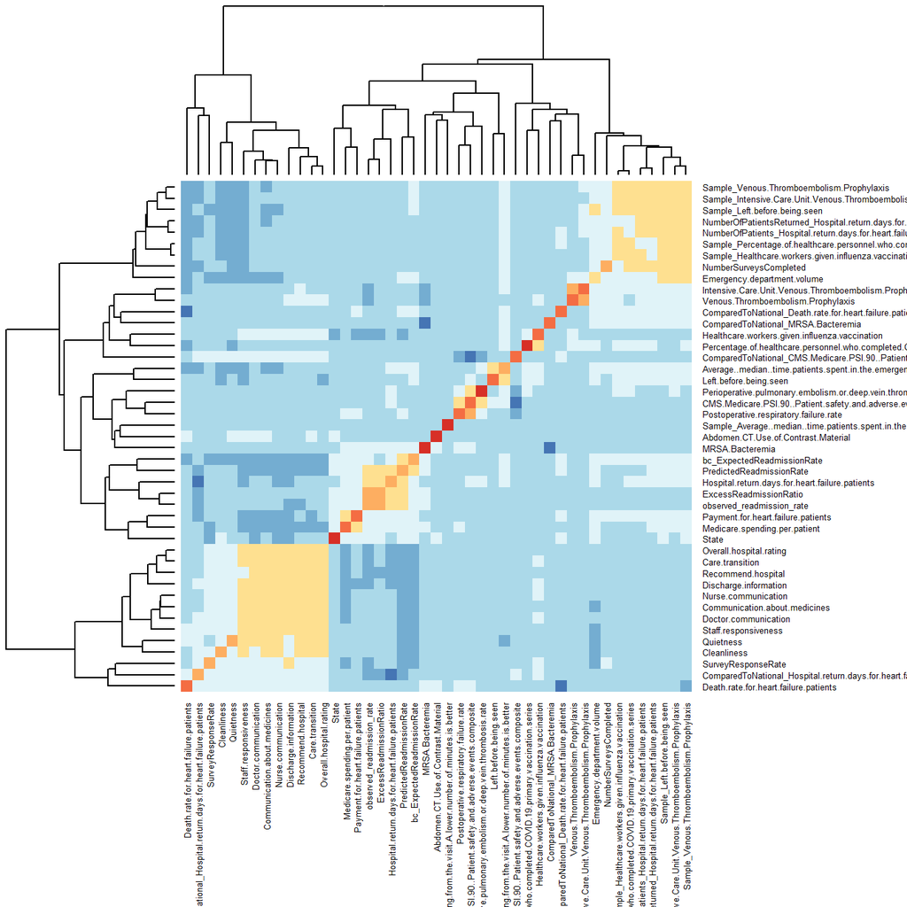

##### **Question 24**: [1 point]

## Ryan C

Where do you see the highest potential for multicollinearity? Why do you say that?

## 4.2 OLS Multiple Linear Regression

### 4.2.1 Fitting a model to estimate VIF

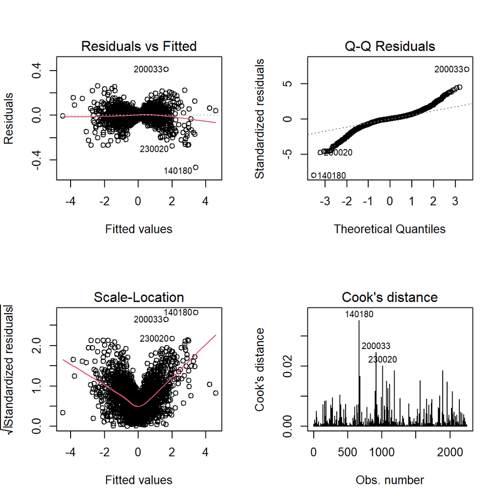

##### **Question 25**: [1 point]

## Ryan C

You may have to do a little outside research, but interpret the four plots that have come off the regression. Do we largely meet the assumptions for an OLS multiple regression? Why or why not?

```r
shapiro.test(residuals(mod))
```

```
##
##  Shapiro-Wilk normality test
##
## data:  residuals(mod)
## W = 0.90622, p-value < 0.00000000000000022
```

### 4.2.2 Estimating the VIF (Variance Inflation Factors)

Table 6. Variance Inflation Factors after multiple linear regression

|  | VIF |
| --- | --- |
| NumberOfPatients_Hospital.return.days.for.heart.failure.patients | 88.35 |
| NumberOfPatientsReturned_Hospital.return.days.for.heart.failure.patients | 87.06 |
| Overall.hospital.rating | 24.53 |
| Sample_Venous.Thromboembolism.Prophylaxis | 20.55 |
| Recommend.hospital | 16.94 |
| Sample_Percentage.of.healthcare.personnel.who.completed.COVID.19.primary.vaccination.series | 11.83 |
| Sample_Healthcare.workers.given.influenza.vaccination | 11.52 |
| Nurse.communication | 9.15 |
| Care.transition | 9.06 |
| Sample_Intensive.Care.Unit.Venous.Thromboembolism.Prophylaxis | 8.39 |
| Sample_Left.before.being.seen | 5.86 |
| observed_readmission_rate | 5.84 |
| Staff.responsiveness | 5.82 |
| Communication.about.medicines | 5.26 |
| ExcessReadmissionRatio | 5.17 |

##### **Question 26**: [1 point]

## Ryan C

Does multicollinearity seem to be an issue in this dataset and, if so, among which variables? Why do you come to this conclusion?